# Scenario Update IIIQ2025

# 6 Transmission Grid

## 6.1 Grid Reinforcements

**SIGNIFICANT GRID REINFORCEMENTS ARE EXPECTED BY THE MID-2020s, WITH MAJOR PROJECTS—SUCH AS THE TYRRHENIAN LINK AND ADRIATIC LINK—SCHEDULED FOR COMPLETION IN THE 2030s. THE LARGE-SCALE EXPANSION OF RENEWABLES WILL DRIVE FURTHER UPGRADES, AS INTER-ZONAL CONSTRAINTS WILL PERSIST**

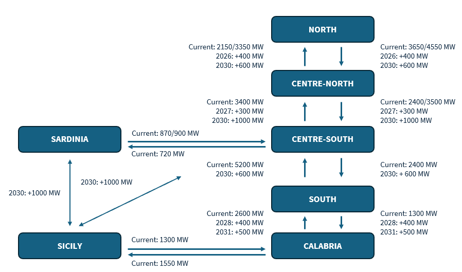

#### 25-26

In all the scenarios proposed, network constraints are aligned with the most recent indications provided by Terna.

#### 27-30

Grid reinforcements are expected to improve flow management and reduce inter-zonal congestion on the mainland. By 2030, two key HVDC infrastructures are set to become operational: the Tyrrhenian Link, key to decommission Sardinia’s coal-fired units, and the Adriatic Link, designed to alleviate bottlenecks between South and North.

#### 31-50

Under BAU assumptions, interzonal constraints on the mainland are expected to gradually ease starting in 2035. In the high RES scenario, Terna’s proposed 30 GW Hypergrid infrastructure is implemented largely in line with Terna’s schedule, while the low RES scenario anticipates more substantial delays in long-term network development.

#### Main updates

We revised our projections for the timeline of Terna’s project implementation based on the 2025 *Piano di Sviluppo della Rete*, incorporating the most recent updates.

# 7 Power Market Prices

## 7.1 Baseload PUN

**THE PUN IS PROJECTED TO RECOVER TO AROUND 119 €/MWH IN 2025, SUPPORTED BY GAS MARKET TENSIONS AND CO2 PRICES STABILIZING AT 74.7 €/TON FOLLOWING FULL ETS REFORM IMPLEMENTATION. HOWEVER, ACCELERATED RES INTEGRATION, GAS PRICE NORMALIZATION AFTER 2026, AND STABLE ELECTRICITY IMPORTS ARE EXPECTED TO DRIVE PRICES BELOW 100 €/MWH BY 2029 IN THE REFERENCE SCENARIO AND AS EARLY AS 2026 IN THE HIGH-RES CASE**

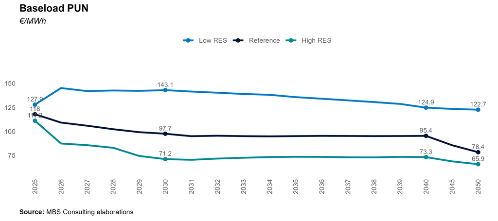

#### 25-26

In the Reference scenario, market dynamics are expected to stabilize by 2026 as the gas market approaches equilibrium. In 2025, gas market tensions and a demand-driven recovery supporting the ETS mechanism are projected to push average prices to approximately €120/MWh, before easing to €109/MWh in 2026. In the High RES scenario, stronger economic conditions and accelerated RES integration may temper price increases, with the PUN forecast to average around €112/MWh in 2025.

#### 27-30

In the medium term, continued electricity imports, gas price normalization—supported by new LNG capacity from the U.S. and Qatar—and rising RES penetration are expected to push prices down. Average electricity prices are projected to fall to €98/MWh by 2030, and to €71/MWh in the High RES scenario.

#### Main updates

The 2025 PUN revision reflects lower CO₂ price assumptions, driven by weak certificate demand and easing market tensions. Medium-term forecasts were also adjusted, with reduced baseload CSS due to lower thermoelectric residual demand and higher expected RES output.

### 7.1.1 Peak-Load/ Off-Peak PUN

**RENEWABLES PENETRATION, DRIVEN BY SOLAR ENERGY, IS ANTICIPATED TO HAVE A SIGNIFICANT IMPACT ON PEAK AND OFF-PEAK DYNAMICS AFTER 2030, WHEN AN INVERSION IN PRICE SPREADS BETWEEN TIME SLOTS IS EXPECTED TO TAKE PLACE**

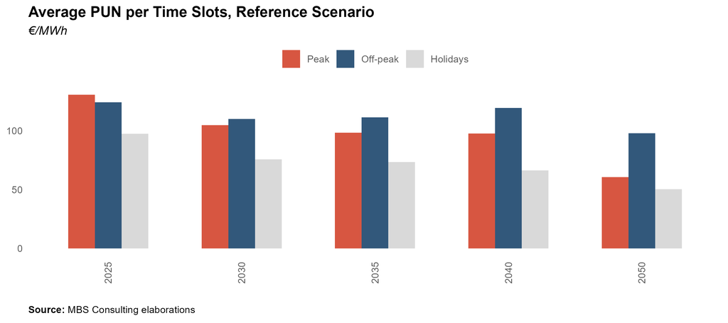

#### 25-26

The favorable price spread between evening and midday hours is anticipated to persist in the short term, as the penetration of renewables remains below 50% of gross domestic consumption.

#### 27-30

The continued expansion of solar capacity is expected to further suppress midday prices, particularly during periods of abundant sunlight and low demand, such as in spring. This trend will progressively narrow the disparity between peak and off-peak prices.

#### 31-50

The long-term persistence of reversed hourly price differentials is expected to drive higher prices during off-peak hours. The growing integration of energy-intensive electrochemical storage systems, coupled with improved storage unit operability, is likely to alleviate the cannibalization effect caused by non-programmable solar power plants.

#### Main updates

The price trends for the various categories of hours align with the findings from the previous market update.

### 7.1.2 Baseload PUN Components, Reference Scenario

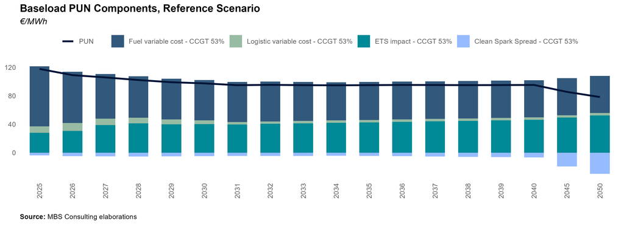

#### 25-26

Sustained net imports from foreign countries and the sluggish recovery in demand heighten market competition for CCGTs, while the moderation of commodity prices exerts downward pressure on the market price. The decreasing room for thermal plants operativity maintain the CSS in negative territory, setting at approximately -3.1 €/MWh in the Reference scenario for 2025.

#### 27-30

In the latter half of the 2020s, intensified competition from newly constructed Capacity Market units, and the growing share of RES are expected to keep the CSS in negative territory, averaging -5 €/MWh, while the CO2 price exceeds 100 €/MWh.

#### 31-50

In the long term, renewables are expected to dominate the generation mix, driving down both power prices and the CSS, which is projected to fall to around -30 €/MWh by 2050. With rising demand and despite a substantial increase in RES penetration, existing CCGTs are expected to remain the marginal technology, setting prices for roughly 80% of system hours in 2040.

#### Main updates

Short-term baseload PUN projections have been updated to reflect the latest commodity and CO₂ price assumptions, while medium-term estimates have been adjusted following the revision of CSS projections driven by changes in power demand and RES generation.

### 7.1.3 PUN Hourly Shape

**INCREASING SOLAR PENETRATION EXERTS SIGNIFICANT PRESSURE ON PRICES DURING PEAK DAYTIME HOURS, WIDENING INTRADAY PRICE DIFFERENTIALS OVER THE LONG TERM. THIS EFFECT IS PARTIALLY MITIGATED BY THE GROWTH OF STORAGE CAPACITY**

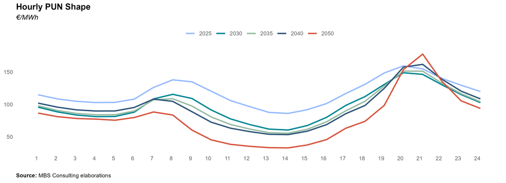

#### 25-26

The surge in solar production observed consistently in the recent past affects both midday price depression and profile skewness, which are increasingly pronounced relative to 2022–2024 averages. This tendency is expected to become even more prominent as solar capacity advances and production grows.

#### 27-30

As solar penetration rises and the cannibalization effect intensifies, the gap between central hours and morning/evening peak prices continues to widen. Although the combined deployment of single-axis trackers, grid upgrades, and energy-intensive storage solutions helps mitigate this imbalance, their overall impact remains limited.

#### 31-50

As renewable penetration grows, intra-day price differentials widen and the frequency of hours with 0 €/MWh prices increases, incentivizing investments in electrolysis capacity. This environment enhances the appeal of time-shifting applications in the Day-Ahead Market and drives new investments in energy-intensive storage systems.

#### Main updates

The PUN hourly shape shows increasing skewness and deeper midday depression, driven by growing solar output. In the short term, it also shifts downward by reflecting the revised short-term PUN projections. Post-2040, the shape features sharper troughs, largely due to a rise in zero-price hours, as recent trends in hourly price evolution are incorporated. These effects are only partially mitigated by BESS capacity expansion. Additionally, the model projects a slightly less pronounced evening peak compared to the 2024 average, reflecting recent price formation patterns and a modest decline in commodity prices, which has been correlated with reduced price profile skewness.

## 7.2 Baseload Zonal Prices

**IN THE SHORT AND MEDIUM TERM, ZONAL PRICES WILL DIVERGE DUE TO VARIATIONS IN SUPPLY-DEMAND BALANCE ACROSS ZONES. IN THE LONG TERM, THE EXPANSION OF RENEWABLES IN THE SOUTHERN MACRO-ZONE, SUPPORTED BY GRID UPGRADES, WILL LOWER BASELOAD PRICES AND NARROW PRICE GAPS**

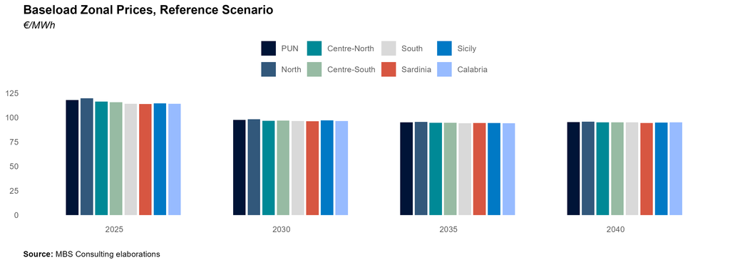

#### 25-26

Network congestion remains limited on the mainland. Southern regions (including Calabria) and the islands record lower prices, while higher CCGT utilization in the North keeps prices above the PUN, in line with recent historical trends. However, with electricity demand still below past levels and renewable penetration progressing gradually, zonal price spreads remain modest—just above €4/MWh in 2025 and below €4.1/MWh in 2026.

#### 27-30

While the rapid expansion of renewables is expected to push zonal prices below €100/MWh in the Reference scenario by 2029, it will temporarily intensify inter-zonal congestion during the second half of the 2020s. Major grid upgrades planned after 2029—most notably the Adriatic Link and Tyrrhenian Link—will reinforce North–South energy flows and progressively ease congestion, keeping price differentials around €3/MWh or lower as 2030 approaches.

#### Main updates

Zonal price dynamics have shifted due to revisions in both demand and renewable output projections, as well as updates to the implementation timeline of grid improvements outlined in Terna’s *Piano di Sviluppo* 2025. The updated zonal prices show wider medium-term spreads, driven by higher renewable output in specific zones and delays in the completion of major grid enhancements.

## 7.3 Evolution of Baseload PUN-South Price Differential

**THE TREND IN THE SPREAD BETWEEN THE PUN PRICE—PRIMARILY INFLUENCED BY THE PERFORMANCE OF THE NORTHERN MARKET ZONE—AND THE PRICES IN THE SOUTHERN MARKET ZONES IS HEAVILY DEPENDENT ON ASSUMPTIONS REGARDING RENEWABLE PENETRATION, STORAGE DEVELOPMENT, AND THE TIMING OF GRID INFRASTRUCTURE IMPLEMENTATION**

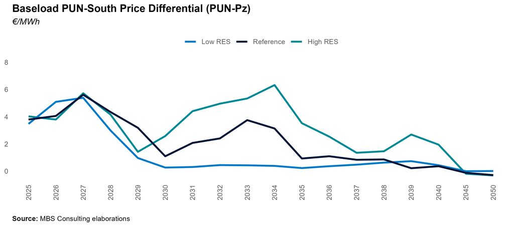

#### 25-26

The spread between the PUN and the Southern market zones is expected to remain at recent historical levels in the short term, with the Southern zone experiencing a discount. This dynamic is driven by a general decrease in electricity demand and an increasing share of RES in the generation mix, leading to lower prices compared to the Northern zones. Despite the rise in import flows, CCGTs in the North are still needed to meet demand, resulting in average prices that are higher.

#### Main updates

The average medium-term spread between the PUN and Southern zonal prices reflects the updated BESS capacity projections across zones.

## 7.4 Clean Spark Spread

### 7.4.1 Baseload CSS for Existing CCGT Units

**BASELOAD CSS IS PROJECTED TO DECLINE IN THE SHORT TERM AS STAGNANT POWER DEMAND GROWTH, SUSTAINED IMPORTS, AND INCREASING RES PENETRATION REDUCE CCGT PRODUCTION. BY 2040, VALUES ARE EXPECTED TO STABILIZE BETWEEN -7 AND -4 €/MWh, DEPENDING ON THE SCENARIO. MISSING MONEY ISSUES ARE LIKELY TO EMERGE IN THE LATTER HALF OF THE 2020s AND BECOME MORE PRONOUNCED IN ALTERNATIVE SCENARIOS**

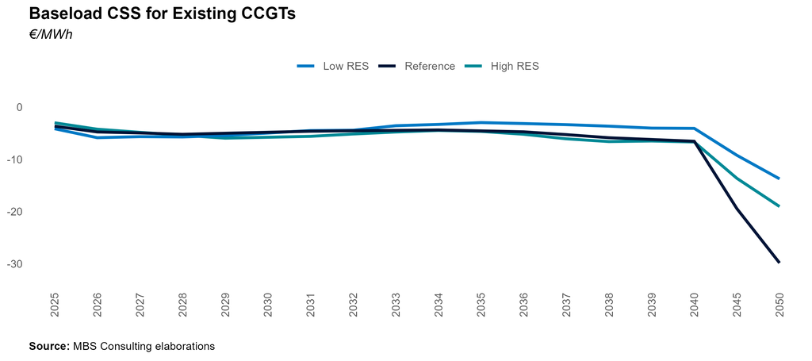

#### 25-26

The anticipated energy outlook—marked by stagnant electricity demand, a rising share of RES, and sustained import levels—is expected to intensify competition for the existing generation fleet. These dynamics will exert downward pressure on the Clean Spark Spread (CSS) for CCGTs, with average values projected at -4.0 €/MWh in the Reference case over the 2025–2026 period.

#### 27-30

Market competition is set to intensify as a result of stabilized imports from Northern borders, expanding renewable capacity, and the addition of new high-efficiency CCGTs through CM auctions. These factors are expected to maintain negative baseload CSS, averaging around -5.5 €/MWh under the High RES scenario, where accelerated RES deployment and increased thermoelectric competition further heighten pressure in the latter half of the 2020s.

#### 31-50

Post-2030, the decommissioning of aging capacity will enable existing CCGTs (53%-efficiency) to remain the marginal technology for approximately 80% of the operating hours through 2040. During this horizon, baseload CSS is expected to range below -4 €/MWh, and until -7 €/MWh. After 2040 baseload CSS is expected to fall below -10 €/MWh across all scenarios, reaching -30 €/MWh by 2050, when CCGTs will only fulfill a support function.

#### Main updates

CSS estimates reflect the upward revision of RES capacity projections as well as the downward contraction of demand projections; short-term projections vary, while medium and long-term values remain broadly consistent with the previous update.

### 7.4.2 Day-Ahead Market Profitability for CCGT Units

**IN THE NEAR TERM, CURRENT UNITS ARE LIKELY TO FACE LESS FAVORABLE SWITCHING CONDITIONS, BUT THE RISING SOLAR PENETRATION IS PROJECTED TO INCREASE EVENING PRICE PEAKS OVER THE MEDIUM TO LONG TERM. HIGH-EFFICIENCY UNITS WILL OPTIMIZE DAM VOLUMES WHILE MAINTAINING A DOUBLE-DIGIT MARGINAL CAPTURE**

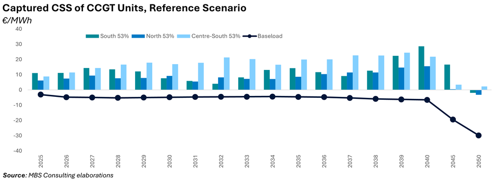

#### 25-26

Differences in energy mix across market zones will significantly affect thermal unit margins. In the South, weak demand and growing RES constrain operability, though peak-hour price spikes sustain captured CSS around 11 €/MWh. In the North, stronger demand supports CCGT utilization, but imports from the Northern border and high RES output compress margins to about 7 €/MWh. The Centre-South, with slower RES expansion and minimal imports, is expected to maintain captured CSS averaging at 10 €/MWh.

#### 27-30

As renewable capacity expands, existing thermal units increasingly concentrate operations in evening hours to maximize captured margins. High-efficiency gas-fired plants face mounting competition from new projects supported by the latest Capacity Market auction. Nonetheless, their superior efficiency enables them to maintain an average captured CSS above 8 €/MWh in the North, while sharper price spikes in the South sustain levels around 10 €/MWh through 2030.

#### Main updates

The expected load factor and marginality of CCGT units show a long-term decline, reflecting updated expectations of CCGT operability following the upward revision of RES-E installed capacity and generation, as well as the decline of short- and medium-term power demand.

## 7.5 Captured Prices of Renewable Sources

### 7.5.1 Solar Captured Prices

**A GROWING CANNIBALIZATION EFFECT ON SOLAR PRICES BECOMES APPARENT IN THE LATE 2020s, PARTICULARLY IN SOUTHERN MARKET ZONES, WHERE HIGH RENEWABLE PENETRATION AND LIMITED INTERCONNECTION CAPACITY WITH NORTHERN ZONES EXACERBATE THE IMPACT**

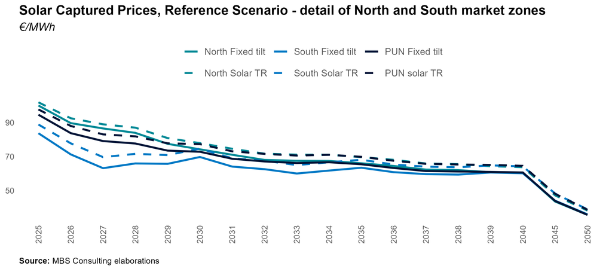

#### 27-30

The rapid growth of renewable energy installations is intensifying cannibalization and overgeneration, with storage and grid upgrades only partially mitigating these effects. As a result, zonal captured prices are diverging from baseload and are expected to fall below €80/MWh by 2030—even in the typically more resilient Northern zones.

#### 31-50

Rising overgeneration highlights the need for energy-intensive storage to help ease the cannibalization effect. After 2030, this issue intensifies—especially for solar captured prices in Southern zones with higher RES penetration. Consequently, long-term Reference captured prices are expected to drop below €40/MWh in both Northern and Southern regions.

#### Main updates

Short-term solar captured price projections are influenced by fluctuations in commodity prices, while medium- and long-term levels decline due to rising projections of RES production.

### 7.5.2 Wind Captured Prices

**WIND GENERATION IS LESS CONCENTRATED THAN SOLAR OUTPUT, WITH PRODUCTION MORE EVENLY DISTRIBUTED BOTH ACROSS SEASONS AND THROUGHOUT THE DAY. THIS BROADER TEMPORAL PROFILE ALLOWS CAPTURED PRICES TO ALIGN WITH — OR EVEN EXCEED — BASELOAD PRICES**

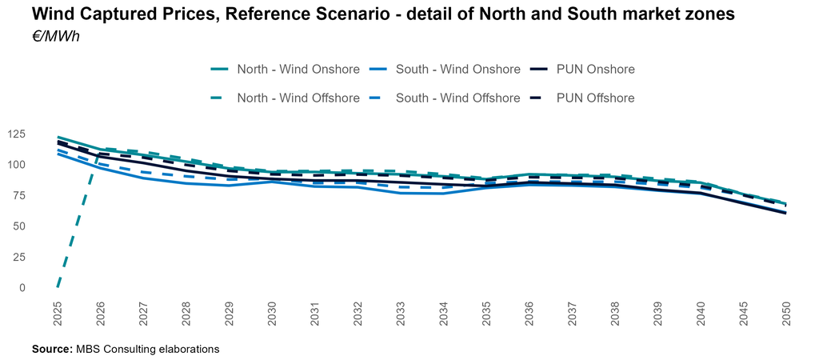

#### 25-26

Captured prices in 2025 closely follow zonal baseload prices, exceeding €100/MWh in all zones. In 2026, they edge lower, reflecting the gradual normalization of the PUN and, even more, the emergence of a more pronounced price profile marked by sharper peaks and troughs.

#### 27-50

Captured prices remain closely aligned with zonal baseload prices over the long term. While increased solar and wind output leads to overgeneration in the early 2030s, outcomes for both technologies are increasingly shaped by zonal market dynamics rather than broader price trends. By 2030, captured prices approach €94/MWh in the Northern zones and €86/MWh in the South, supported by a more balanced production profile across both time of day and season.

#### Main updates

Short-term solar capture price projections are shaped by commodity price volatility, while medium- and long-term levels decline due to rising RES output, particularly from offshore capacity expansion. The rising share of RES generation—particularly solar—is reshaping hourly price patterns, deepening midday dips and increasing profile skewness; this dynamic, reflected in the current update, intensifies downward pressure on wind capture prices, especially over the medium and long term.

### 7.5.3 Investment costs and IRR of Solar and Wind

**INTENSE COMPETITION IN THE PV MODULES MARKET DRIVES DOWN INVESTMENT COSTS FOR SOLAR IN THE MID AND LONG TERM, EVEN THOUGH GRID CONNECTION AND LAND COSTS MAY RISE. HIGHER TECHNOLOGY COSTS FOR WIND**

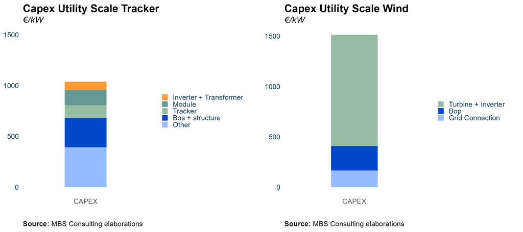

#### Solar

Intense competition in the PV module market—led primarily by Chinese manufacturers—has reduced module costs to around €100.000/MW. Polysilicon, while inexpensive, accounts for about 30% of this cost and remains highly price-volatile. Scarce materials like silver could further increase costs in the future. Due to competitive pricing, PV modules represent just 15% of total solar CAPEX. Two major cost drivers are grid connection—expected to rise as projects shift to remote areas—and land acquisition or rental, which now makes up about 8% of CAPEX and is increasing due to growing land demand. These factors typically yield a base-case IRR of 7% for solar projects in the South (pre-tax, 30-year horizon), with regional variations based on captured prices. Agri-voltaic projects require a 20–40% investment premium, lowering expected IRRs to around 6%.

#### Main updates

The cost structure for both solar and wind technologies is in line with the previous update.

### 7.5.4 Hydro Run-of-River Captured Prices

**HYDROPOWER GENERATION IS MORE SENSITIVE TO SEASONAL WATER INFLOWS TRENDS THAN TO HOURLY VARIABILITY, SO THAT CAPTURED PRICES REMAIN BASICALLY IN LINE WITH BASELOAD PRICES**

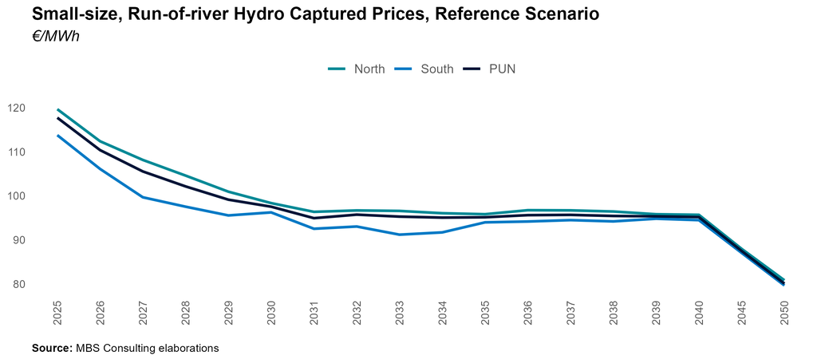

#### 25-26

Captured prices closely align with zonal baseload prices and reflect increased power prices, averaging 114 €/MWh.

#### 27-50

Captured prices are expected to remain closely aligned with zonal baseload prices over the long term. While overgeneration driven by increased solar output significantly affects the early 2030s, the performance of both solar and wind remains more influenced by zonal market dynamics than by shifts in price structure. Moreover, both technologies benefit from a production profile that is more evenly distributed across hours of the day and throughout the year.

#### Main updates

Short-term outcomes are supported by commodity price trends and their influence on electricity prices, while mid- and long-term results remain consistent with the previous update.

# 8 Ancilliary Services & Fuels Mix

## 8.1 Ancilliary Services Volumes, Reference Scenario

**THE DEMAND FOR ANCILLARY SERVICES IS EXPECTED TO REMAIN BELOW RECENT LEVELS DUE TO CHANGES IN SYSTEM MANAGEMENT STRATEGIES IMPLEMENTED BY THE TSO AND INVESTMENTS IN GRID INFRASTRUCTURE AT CRITICAL NODES. HOWEVER, IN THE LONG TERM, THE EXPANSION OF RENEWABLE ENERGY CAPACITY IS LIKELY TO DRIVE AN INCREASED NEED FOR SYSTEM SERVICES**

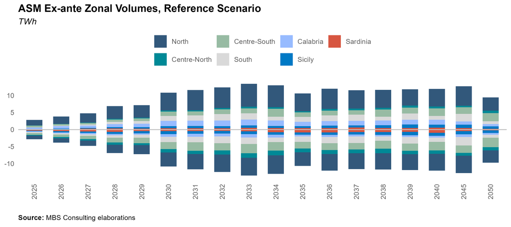

#### 25-26

Procured ex-ante ancillary services volumes are expected to partially recover from 2022 but will remain below historical levels due to: (i) availability of thermoelectric reserves, (ii) changes in network management practices by Terna since the 2022 cost-containment scheme, and (iii) feasibility intervals imposed on power plants under the new Intra-Day Market structure.

#### 27-30

The phase-out of coal-fired units on the mainland and the growing share of renewables in the energy mix are offset by the entry of (i) new thermoelectric and energy-intensive storage capacity supported by the Capacity Market, and (ii) the rollout of power-intensive BESS, which will reduce the need for ex-ante scheduling by increasing system flexibility.

#### 31-50

The increasing share of renewables in the energy mix will be balanced by (i) the addition of new thermoelectric capacity and storage systems supported by the Capacity Market mechanism and MACSE. This is expected to reduce the need for ex-ante scheduling, thanks to the greater availability of flexible resources within the system.

#### Main updates

ASM volumes reflect recent structural market trends across the simulated period. Upward and downward volumes are symmetric in our model, due to the deterministic simulation approach. Estimates exclude the contingent portion of the balancing market associated with real-time imbalances.

## 8.2 Ancilliary Services Volumes, Alternative Scenario

**ANCILLARY SERVICES EX-ANTE VOLUMES EVOLVE ACCORDING TO THE COMPOSITION OF THE GENERATION MIX AND DAM DYNAMICS IN THE DIFFERENT SCENARIOS. IN THE POST-2030 SCENARIO, STORAGE SYSTEMS AND GRID REINFORCEMENTS ARE EXPECTED TO LIMIT THE EXPANSION TREND IN THE THREE SCENARIOS**

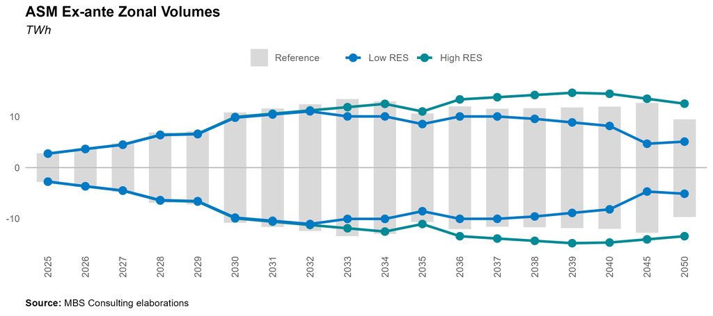

#### 25-26

Procured ex-ante ancillary services volumes are projected to remain low compared to recent levels in the alternative scenarios as well, with variations arising from the differing degrees of competition in the thermoelectric sector within the Day-Ahead Market. This competition results in varying levels of running reserves.

#### 27-30

In the High RES scenario, the rapid growth of non-programmable renewables is offset by grid enhancements and accelerated deployment of energy-intensive storage. In contrast, the Low RES scenario features a rise in less flexible resources, driving higher demand for secondary reserve volumes.

#### 31-50

In the High RES scenario, ongoing grid development and strong growth in energy-intensive storage help contain ASM volumes. In contrast, in the Low RES scenario, ASM volumes remain stable due to a higher share of CCGTs in the Day-Ahead Market and continued coal plant operation until 2035. Energy-intensive storage also enhances system regulation.

#### Main updates

ASM short-term volumes incorporate the variations in commodities level.

## 8.3 Ancilliary Services Market prices

**GRID BOTTLENECK RESOLUTION AND THE PENETRATION OF BESS ARE KEY DRIVERS OF FUTURE COMPETITIVE DYNAMICS IN THE ANCILLARY SERVICES MARKET. THE CAPACITY MARKET STRIKE PRICE (FOR DELIVERY YEARS) MAY EMERGE AS THE REFERENCE UPPER PRICE, SIGNIFICANTLY AFFECTING THE CENTRE-SOUTH MARKET ZONE.**

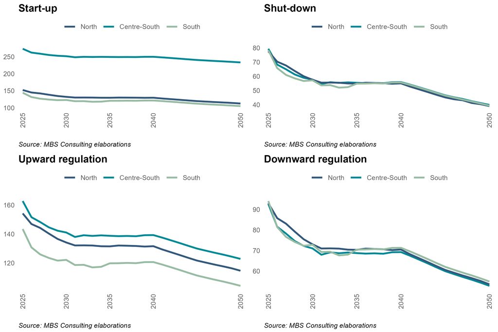

#### 25-26

In the delivery years of the Capacity Market’s, the strike price is anticipated to exert a cap on prices for start-up and upward regulation, particularly in the Centre-South market zone. However, the decline in ASM volumes may promote increased price competition across Italy compared to previous years.

#### 27-50

Price competition in the ancillary services market is expected to increase gradually as innovative technological solutions, such as electrochemical storage, become available at more competitive prices. Assuming the extension of the capacity remuneration mechanism, the strike price, along with the Levelized Cost of Storage (LCOS) of batteries, could emerge as key factors shaping ancillary services prices in the future.

#### Main updates

Price projections are derived from a statistical approach that analyzes the historical bidding strategies of market participants in the ancillary services market. It is assumed that the historical distributions of price spreads between Day-Ahead Market (DAM) and ancillary services prices for each type of service will remain constant in the future. In comparison to the previous release, the updated short-term price projections for ancillary services now reflect the impacts of revised assumptions regarding DAM dynamics and prices.

# 9 Our Suite of Market Models

[figure not shown]

ELFO ++ suite has been included among the benchmark models for energy systems’ planning in the World Bank database and it is included in the top list of electricity market simulation models prepared in 2017 by the Joint Research Center of European Commission. ELFO ++suite and its database are used for research acvities in numerous universities with which REF-E has a consolidated collaboration (Florence School of Regulation, University of Milan-Bicocca, Bocconi University, Milan Catholic, Milan Polytechnic, Turin Polytechnic, University of Pavia, University of Padua, University of Verona, others).

# 10 Acronyms

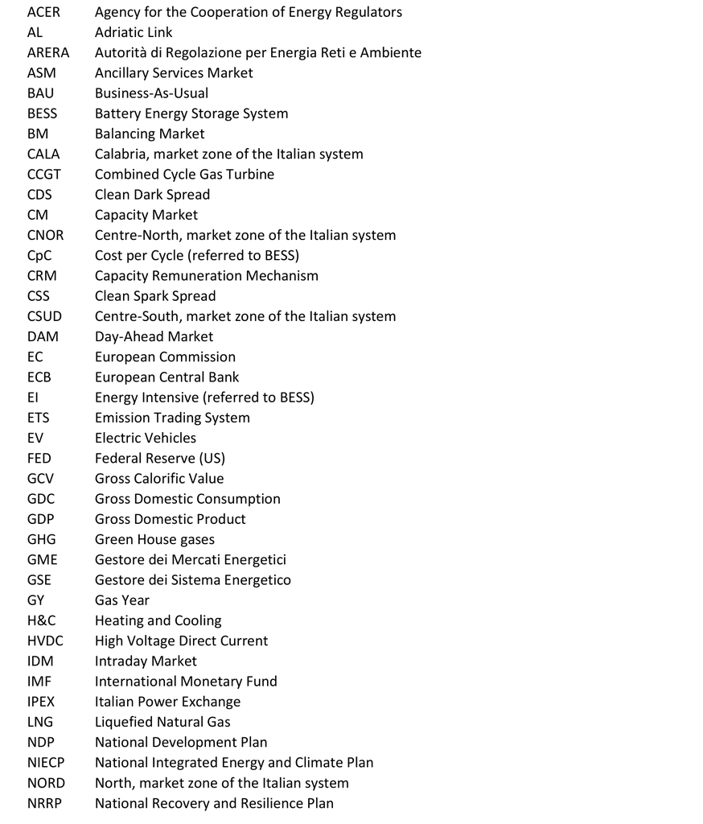

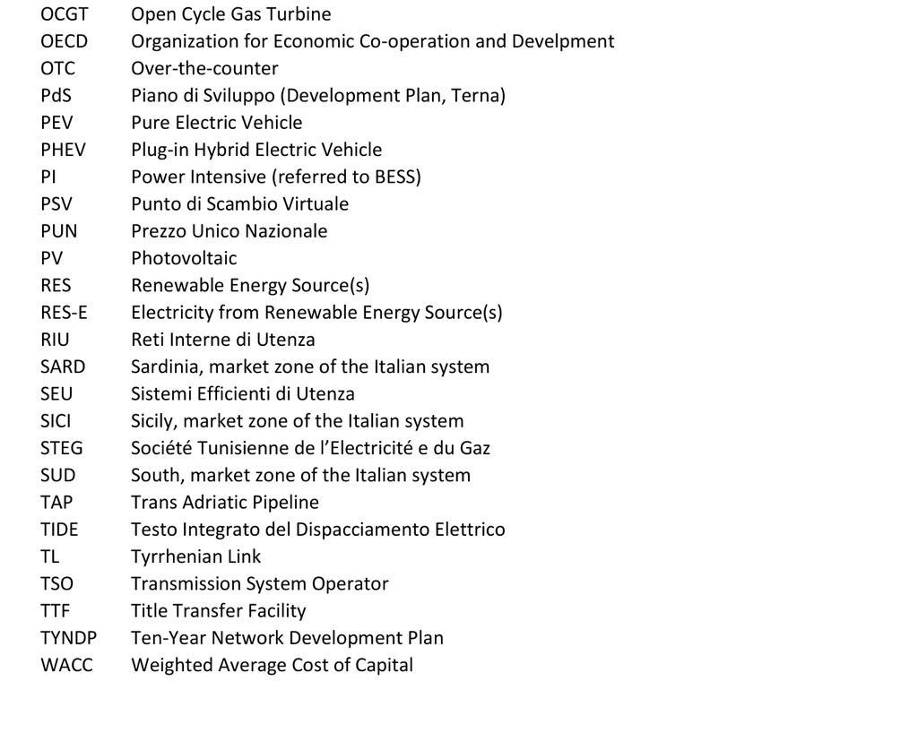